# CMSC320 - Basic data science tutorial in R

This tutorial will cover the steps of a basic data science flow, covering topics like data curation, parsing, and management, exploratory data analysis, hypothesis testing, and machine learning. All the code provided is running in R 3.5.2.

### Part 1 - Data curation / parsing / management

The first thing we’d like to do is find a topic to get insight for. Because college admissions are an active area that many students would like insight into, it seems to be a salient task to use data science and see what we can glean from a sample dataset. The dataset we’ll be using for this tutorial, sourced from a post on Kaggle.com, is an Indian admission data set for a Master’s program. It can be found at https://www.kaggle.com/mohansacharya/graduate-admissions. Because it seems to be a fairly objective process, and because of the amount of data at the individual level that is given, this seems to be a good dataset to allow us to gain some insight as to how the admissions process works.

To begin, we’ll load in our dataset, which is hosted on Github at https://dtschleckser.github.io/data.html (as a lot of real-world data is not easily available in a downloaded CSV, it’s been re-hosted as an HTML table). First, we need to load in our libraries. Tidyverse is the library we’ll be using for this tutorial that allows us to manipulate data. We’ll use broom in a few cases to make data more presentable, and rvest to scrape web data.

```r
library(tidyverse)
library(broom)
library(rvest)
```

Now that we have our libraries loaded, we’ll scrape the table from our web page. It’s identifiable as the only table with class “waffle” on the page, so we’ll use that to specify that it’s what we want to scrape with html_node. We’ll use html_table() to get the table as a data frame.

```r
url <- "https://dtschleckser.github.io/data.html"
admissions_table <-
  read_html(url) %>%
  html_node(".waffle") %>%
  html_table()
```

Now that we’ve loaded in the libraries we need and scraped our webpage for the table containing our data, let’s see the first 10 rows of our data set.

```r
admissions_table[1:10,]
```

```
##
## 1   1 Serial No. GRE Score TOEFL Score University Rating SOP LOR CGPA
## 2   2          1       337         118                 4 4.5 4.5 9.65
## 3   3          2       324         107                 4   4 4.5 8.87
## 4   4          3       316         104                 3   3 3.5    8
## 5   5          4       322         110                 3 3.5 2.5 8.67
## 6   6          5       314         103                 2   2   3 8.21
## 7   7          6       330         115                 5 4.5   3 9.34
## 8   8          7       321         109                 3   3   4  8.2
## 9   9          8       308         101                 2   3   4  7.9
## 10 10          9       302         102                 1   2 1.5    8
##
## 1  Research Chance of Admit
## 2         1            0.92
## 3         1            0.76
## 4         1            0.72
## 5         1             0.8
## 6         0            0.65
## 7         1             0.9
## 8         1            0.75
## 9         0            0.68
## 10        0             0.5
```

The data may look okay at first, but it needs to be cleaned to make it more usable by R. There are extra columns on the left that just count up, and R won’t recognize that the top row is the identifier for the column.

To start fixing this, we’ll rename the columns so that we can use them more easily. Because the names are in the first row, we can extract them easily by referring to them with row and column indices. The name() function renames the given column for the given table. We can also see the data in a more readable format in R because we’ve named the columns; we don’t have to include the first row to see what the column is. We’ll use table %>% sample_n(n) in the future, which samples n rows from the table.

```r
names(admissions_table)[2] = admissions_table[1,2]
names(admissions_table)[3] = admissions_table[1,3]
names(admissions_table)[4] = admissions_table[1,4]
names(admissions_table)[5] = admissions_table[1,5]
names(admissions_table)[6] = admissions_table[1,6]
names(admissions_table)[7] = admissions_table[1,7]
names(admissions_table)[8] = admissions_table[1,8]
names(admissions_table)[9] = admissions_table[1,9]
names(admissions_table)[10] = admissions_table[1,10]

admissions_table[1:10,]
```

```
##       Serial No. GRE Score TOEFL Score University Rating SOP LOR CGPA
## 1   1 Serial No. GRE Score TOEFL Score University Rating SOP LOR CGPA
## 2   2          1       337         118                 4 4.5 4.5 9.65
## 3   3          2       324         107                 4   4 4.5 8.87
## 4   4          3       316         104                 3   3 3.5    8
## 5   5          4       322         110                 3 3.5 2.5 8.67
## 6   6          5       314         103                 2   2   3 8.21
## 7   7          6       330         115                 5 4.5   3 9.34
## 8   8          7       321         109                 3   3   4  8.2
## 9   9          8       308         101                 2   3   4  7.9
## 10 10          9       302         102                 1   2 1.5    8
##    Research Chance of Admit
## 1  Research Chance of Admit
## 2         1            0.92
## 3         1            0.76
## 4         1            0.72
## 5         1             0.8
## 6         0            0.65
## 7         1             0.9
## 8         1            0.75
## 9         0            0.68
## 10        0             0.5
```

Next, let’s remove the “Serial No.” and first column (as it’s just a counting number that increments by 1 for every student). We’ll also remove the first row, which contains the names of the columns that we took earlier. To clean up the data itself, we’ll make the appropriate columns into numbers, as they were originally just plain characters, and convert the “Chance of Admit” column to a percentage. We’ll also rename each of the columns to make them more usable later on (you can’t refer to a column with spaces in its name easily).

```r
admissions_table[1] <- NULL
admissions_table <- admissions_table %>% rename(admit_chance = "Chance of Admit", uni_rating = "University Rating", gre_score = "GRE Score", toefl_score = "TOEFL Score")

admissions_table <- admissions_table %>% filter(gre_score != "GRE Score")

#convert each column to a numeric column instead of character as approporiate
admissions_table$gre_score = as.numeric(admissions_table$gre_score)
admissions_table$toefl_score = as.numeric(admissions_table$toefl_score)
admissions_table$uni_rating = as.numeric(admissions_table$uni_rating)
admissions_table$SOP = as.numeric(admissions_table$SOP)
admissions_table$LOR = as.numeric(admissions_table$LOR)
admissions_table$CGPA = as.numeric(admissions_table$CGPA)
admissions_table$Research = as.numeric(admissions_table$Research)
admissions_table$admit_chance = as.numeric(admissions_table$admit_chance)

admissions_table <- admissions_table %>% mutate(admit_percentage = 100 * admit_chance)
admissions_table <- admissions_table %>% mutate(has_research = ifelse(Research == 1, "true", "false"))
admissions_table <- admissions_table %>% select(-("Serial No."))
admissions_table <- admissions_table %>% select(-(admit_chance))
admissions_table <- admissions_table %>% select(-(Research))
admissions_table <- admissions_table %>% select(gre_score, toefl_score, uni_rating, SOP, LOR, CGPA, admit_percentage,has_research)

admissions_table %>% sample_n(10)
```

```
##     gre_score toefl_score uni_rating SOP LOR CGPA admit_percentage
## 86        319         103          4 4.5 3.5 8.66               76
## 196       307         107          2 3.0 3.5 8.52               78
## 49        321         110          3 3.5 5.0 8.85               82
## 26        340         120          5 4.5 4.5 9.60               94
## 60        311         104          2 2.0 2.0 8.30               42
## 281       311         102          3 4.5 4.0 8.64               68
## 270       308         108          4 4.5 5.0 8.34               77
## 372       324         110          3 3.5 3.0 9.22               89
## 251       320         104          3 3.0 2.5 8.57               74
## 234       304         100          2 2.5 3.5 8.07               64
##     has_research
## 86         false
## 196         true
## 49          true
## 26          true
## 60         false
## 281         true
## 270        false
## 372         true
## 251         true
## 234        false
```

The select function returns a dataframe with the columns we selected, in this case, all the columns except serial number. The rename function simply renames columns, and the mutate function makes a new row according to the formula we gave, which is 100 * the original column, a number between 0 and 1.

Luckily, our data set does not have any cells with missing or invalid data past the first few rows and columns; if it did, we’d have to code for those or otherwise clean them up past what we did in the beginning of the tutorial.

### Part 2. Graphing / exploratory data analysis

To get a better idea of how the data looks and how each of the attributes are distributed among applicants, we can graph them out. We can start with their CGPA.

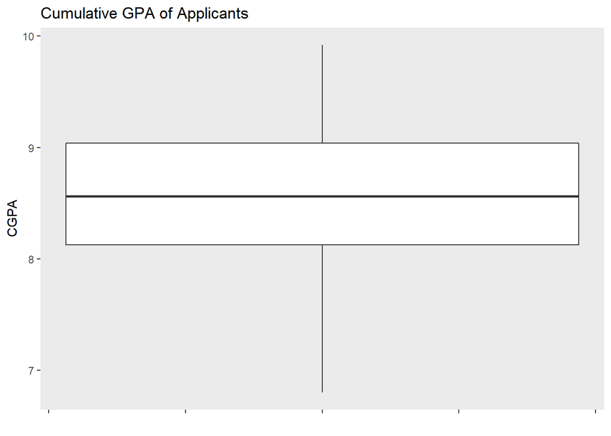

```r
admissions_table %>%
  ggplot(mapping=aes(y=CGPA)) +
    geom_boxplot() +
        labs(
        title="Cumulative GPA of Applicants",
        x = "",
        y = "CGPA") +
    theme(legend.position = "none",
        panel.grid = element_blank(),
        axis.text.x = element_blank())
```

GGPlot lets you specify many attributes for the graph, many of which are useful depending on the use case. For example, above, we used label customization and theming. Typically, though, you’ll only need to specify the data source in the “mapping” parameter and the type of graph you’re making with it; this is the geom_x() parameter (where x is the type of graph you want to display).

We can see that the median GPA is a little higher than an 8.5, and the dataset ranges from a high 6 to a high 9.

A more useful graphical analysis, however, is plotting variables against each other and looking at the relationships that arise.

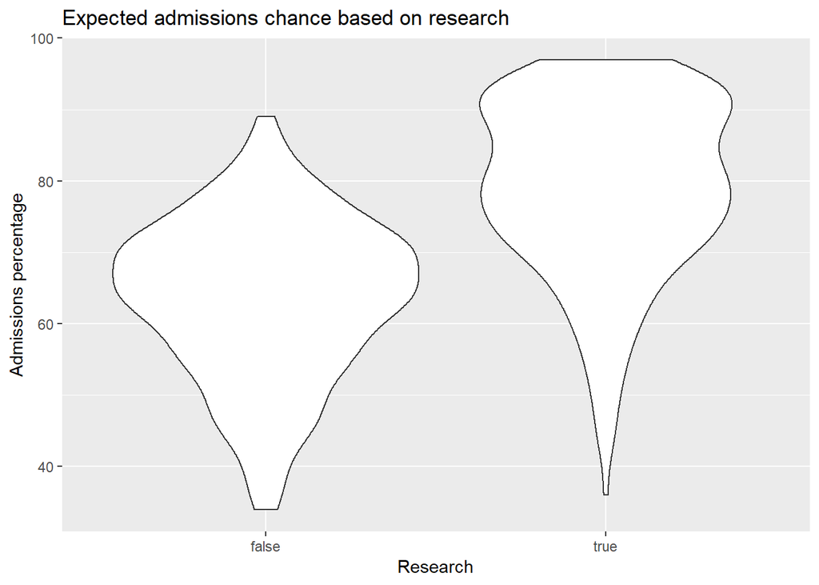

```r
admissions_table %>%
  ggplot(
    aes(x=factor(has_research), y=admit_percentage)) +
    geom_violin() +
    labs(
         title="Expected admissions chance based on research",
         x = "Research",
         y = "Admissions percentage")
```

As we can see from the violin plot, research seems to be a pretty good predictor of whether or not a student will get into the program. However, we can’t say it’s causal because this is almost certainly confounded by other variables, some of which we have data for and some of which we don’t. For example, a student with low grades would be less likely to get opportunities to do research in the first place. Let’s graph some of the factors we have data on.

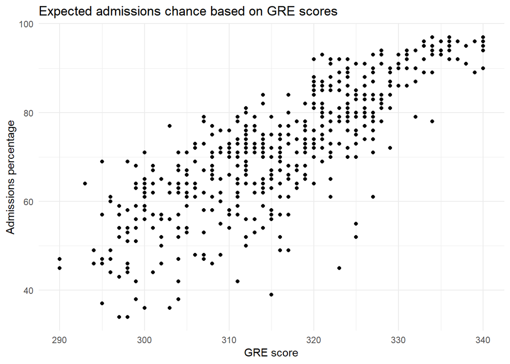

```r
admissions_table %>%
  ggplot(aes(x=gre_score, y=admit_percentage)) +
    geom_point() +
    theme_minimal() +
    labs(
         title="Expected admissions chance based on GRE scores",
         x = "GRE score",
         y = "Admissions percentage")
```

TOEFL is the “Test of English as a foreign language” test. Let’s see how that compares next to the GRE as a predictor for admissions percentage:

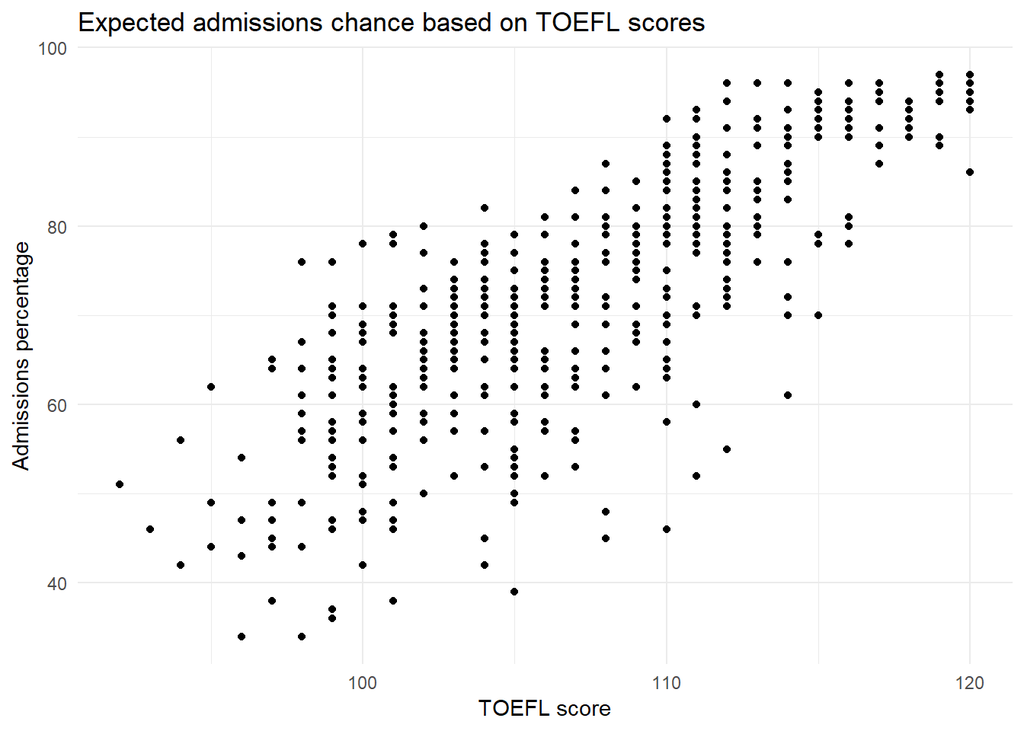

```r
admissions_table %>%
  ggplot(aes(x=toefl_score, y=admit_percentage)) +
    geom_point() +
    theme_minimal() +
    labs(
         title="Expected admissions chance based on TOEFL scores",
         x = "TOEFL score",
         y = "Admissions percentage")
```

From visual analysis alone, TOEFL and GRE scores both appear to be decent predictors as to whether or not someone will have a high admissions chance However, on closer examination, TOEFL appears to have a somewhat wider spread of admissions percentages at each TOEFL score, meaning it’s a marginally worse predictor. Its minimum and maximum score are also closer together, so it’s less granular in its ability to predict.

Next, let’s test CGPA. We would expect this to be a stronger predictor than both of the other scores. If it’s analogous to the undergraduate admissions process, GPA is typically more important than SAT or ACT (similarly standardized tests) for admission.

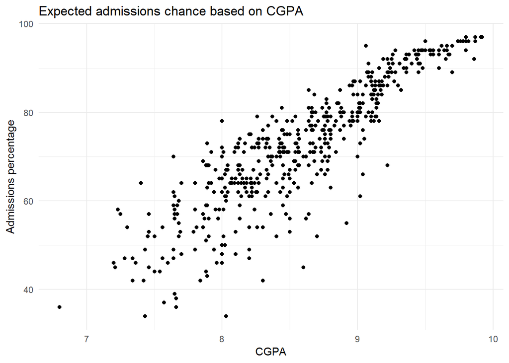

```r
admissions_table %>%
  ggplot(aes(x=CGPA, y=admit_percentage)) +
    geom_point() +
    theme_minimal() +
    labs(
         title="Expected admissions chance based on CGPA",
         x = "CGPA",
         y = "Admissions percentage")
```

This seems to be a much stronger relationship than the other two. Though we don’t expect this to be as important, let’s test out one final parameter, the letter of recommendation:

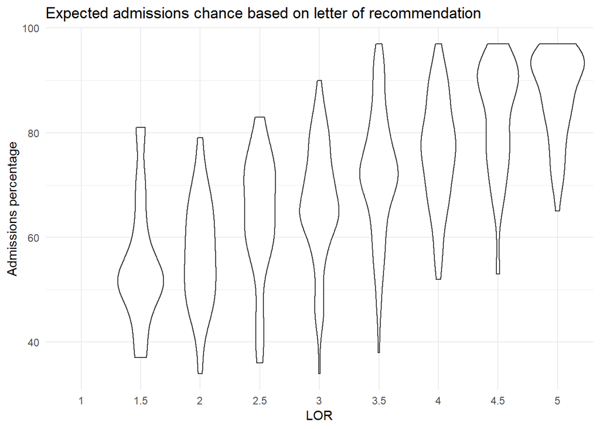

```r
admissions_table %>%
  ggplot(aes(x=factor(LOR), y=admit_percentage)) +
    geom_violin() +
    theme_minimal() +
    labs(
         title="Expected admissions chance based on letter of recommendation",
         x = "LOR",
         y = "Admissions percentage")
```

It appears we’re correct. Let’s see if we can make something useful out of these insights.

### Part 3. Hypothesis testing / machine learning

We’ll create a hypothesis to test; say, that the GRE, TOEFL, letter of recommendation score, and CGPA all have a statistically significant link to the admissions percentage.

Let’s do a linear regression using all of those variables to test this. Our null hypothesis in running this analysis is that both the TOEFL score and the GRE score are not predictors of admissions, and that the difference between students who have high and low admissions predictions can be chalked up to random noise. We’ll probably be wrong about this considering that the data was included in the dataset as a factor in the first place.

```r
linear_fit <- admissions_table %>%
  lm(formula = admit_percentage ~ toefl_score + gre_score + CGPA + LOR) #linear fit using formula admit_percentage = toefl_score + gre_score + CGPA + LOR (letter of recommendation)
af_stats <- linear_fit %>%
  tidy() #tidy the data and display
af_stats
```

```
## # A tibble: 5 x 5
##   term        estimate std.error statistic  p.value
##   <chr>          <dbl>     <dbl>     <dbl>    <dbl>
## 1 (Intercept) -150.       9.02      -16.6  9.65e-50
## 2 toefl_score    0.289    0.0873      3.32 9.83e- 4
## 3 gre_score      0.244    0.0487      5.01 7.55e- 7
## 4 CGPA          12.5      0.942      13.2  2.05e-34
## 5 LOR            2.06     0.383       5.37 1.20e- 7
```

Here’s our augmented linear fit, which gives us various statistics for each row.

```r
aug <- linear_fit %>% augment()
```

Let’s try plotting the residuals against the GRE scores and see if our model is more or less accurate for high and low scoring students. We’ll have to segment the data ourselves so we actually split the data into a readable set of graphs.

```r
#segment the GRE scores into increments of 10
aug <- aug %>% mutate(gre_segments =
                        ifelse(gre_score >= 290 & gre_score <= 300, "290-300",
                          ifelse(gre_score >= 300 & gre_score <= 310, "300-310",
                            ifelse(gre_score >= 310 & gre_score <= 320, "310-320",
                              ifelse(gre_score >= 320 & gre_score <= 330, "320-330",
                                ifelse(gre_score >= 330 & gre_score <= 340, "330-340","Unknown score")
                              )
                            )
                          )
                        )
                      )

aug %>% sample_n(10)
```

```
## # A tibble: 10 x 13
##    admit_percentage toefl_score gre_score  CGPA   LOR .fitted .se.fit
##               <dbl>       <dbl>     <dbl> <dbl> <dbl>   <dbl>   <dbl>
##  1             82           111       324  9.01   3      79.5   0.484
##  2             93           116       331  9.38   5      91.4   0.556
##  3             85           110       322  8.64   5      78.2   0.653
##  4             73           104       323  8.44   4      72.2   0.660
##  5             79           109       313  9      3.5    77.2   0.572
##  6             75           110       325  8.76   2.5    75.3   0.581
##  7             80           110       322  8.67   2.5    73.5   0.536
##  8             84           111       327  9      4.5    83.2   0.446
##  9             74           106       319  8.33   2.5    67.4   0.493
## 10             57.0          99       295  7.65   3      52.0   0.615
## # ... with 6 more variables: .resid <dbl>, .hat <dbl>, .sigma <dbl>,
## #   .cooksd <dbl>, .std.resid <dbl>, gre_segments <chr>
```

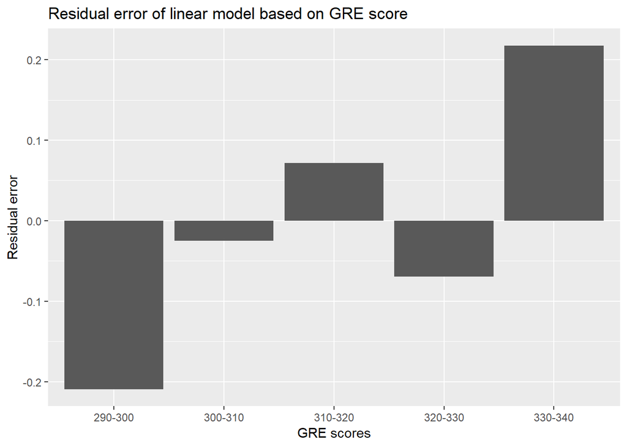

```r
aug <- aug %>% rename(residuals=".resid")
aug <- aug %>% group_by(gre_segments)

summary <-
  aug %>% summarize(resid_mean=mean(residuals)) #can't do it with .resid in quotes, have to rename first

summary %>%
  ggplot(
    aes(x=factor(gre_segments), y=resid_mean)) +
    geom_bar(stat="identity") +
    labs(
         title="Residual error of linear model based on GRE score",
         x = "GRE scores",
         y = "Residual error")
```

Though the residual increases for 330-340 GRE scores, this may be because there are fewer values at that range, so the model does not account as well for them and underestimates admissions chance. This is around what we expected, though; the model will predict fairly accurately at every score because the data itself is fairly linear. This means that we don’t need to really go into more complex models for classification and regression; supervised learning for simple regressions should be enough.

To expand upon the linear regression we have now, though, let’s try graphing it. We’ll have to make a graph and regression for each of the variables compared to admission rate.

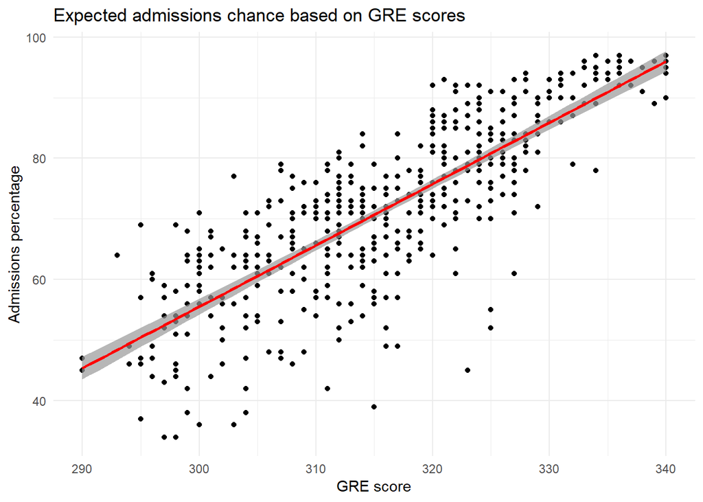

```r
admissions_table %>%
  ggplot(aes(x=gre_score, y=admit_percentage)) +
    geom_point() +
    geom_smooth(method=lm, alpha=0.7, colour = "red") +
    theme_minimal() +
    labs(
         title="Expected admissions chance based on GRE scores",
         x = "GRE score",
         y = "Admissions percentage")
```

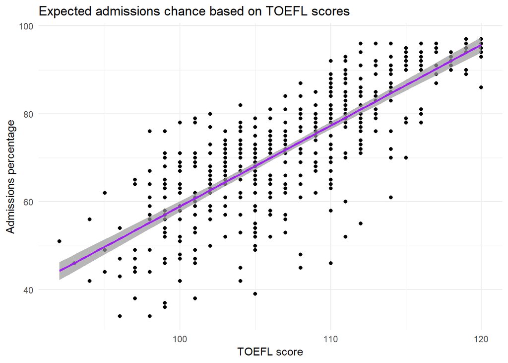

```r
admissions_table %>%
  ggplot(aes(x=toefl_score, y=admit_percentage)) +
    geom_point() +
    geom_smooth(method=lm, alpha=0.7, colour = "purple") +
    theme_minimal() +
    labs(
         title="Expected admissions chance based on TOEFL scores",
         x = "TOEFL score",
         y = "Admissions percentage")
```

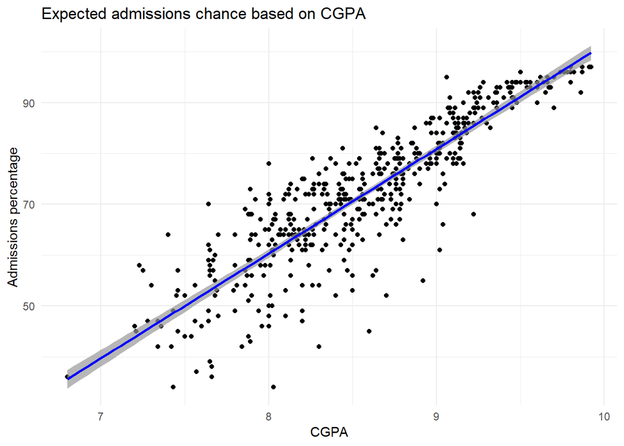

```r
admissions_table %>%
  ggplot(aes(x=CGPA, y=admit_percentage)) +
    geom_point() +
    geom_smooth(method=lm, alpha=0.7, colour = "blue") +
    theme_minimal() +
    labs(
         title="Expected admissions chance based on CGPA",
         x = "CGPA",
         y = "Admissions percentage")
```